# Matching Exercises

Pablo Bello

2023-03-18

```r
###--- Libraries
library(survey)
library(broom)
library(cobalt)
library(MatchIt)
library(WeightIt)
library(tidyverse)
library(ggpubr)
library(tidyr)
library(glue)
library(kableExtra)
library(pbapply)
library(glue)
```

```r
###--- Graphic options
theme_set(theme_pubr(border = TRUE))
```

```r
load("week_9/exercises/exercise_data.RData")


tbl_exp <-
  d_exper |>
  as_tibble() |>
  mutate(treat = as_factor(treat)) |>
  mutate(across(matches("re[0-9+]"), ~. * 1000))

tbl <-
  d |>
  as_tibble() |>
  mutate(treat = as_factor(treat)) |>
  mutate(across(matches("re[0-9+]"), ~. * 1000))

rm(d_exper,d)

tbl
```

```
## # A tibble: 2,510 × 12
##    treat   age  educ black  hisp married nodegr  re74  re75  re78   u74   u75
##    <fct> <int> <int> <int> <int>   <int>  <int> <dbl> <dbl> <dbl> <dbl> <dbl>
##  1 0        47    12     0     0       0      0     0     0     0     1     1
##  2 0        44    12     0     0       0      0     0     0     0     1     1
##  3 0        47    12     0     0       1      0     0     0     0     1     1
##  4 0        25    12     1     0       0      0     0     0     0     1     1
##  5 0        44    12     0     0       1      0     0     0     0     1     1
##  6 0        50    12     1     0       1      0     0     0     0     1     1
##  7 0        49    14     0     0       1      0     0     0     0     1     1
##  8 0        55    13     0     1       1      0     0     0     0     1     1
##  9 0        52    12     0     0       1      0     0     0     0     1     1
## 10 0        52    15     0     0       1      0     0     0     0     1     1
## # … with 2,500 more rows
```

```r
###--- Formulas
f1_bin <- reformulate(termlabels = "black + hisp + married + nodegr + u74 + u75",
                  response = "treat")


f2_lin <- reformulate(termlabels = "age + educ + black + hisp + married + nodegr + re74 + re75 + u74 + u75",response = "treat")


f3_quad <- reformulate(termlabels = "age + I(age^2) + educ +  I(educ^2) + black + hisp + married + nodegr + re74 + I(re74^2) + re75 + I(re75^2) + u74 + u75",
                  response = "treat")


f4_outcome <- reformulate(termlabels = "treat + age + I(age^2) + educ +  I(educ^2) + black + hisp + married + nodegr + re74 + I(re74^2) + re75 + I(re75^2) + u74 + u75",
                  response = "re78")

f5_outcome <- reformulate(termlabels = "treat",
                  response = "re78")
```

### Question 1

Use the experimental data to estimate the effect of the job training treatment. How much does it appear to affect 1978 income? Now look at the observational data (for all exercises from now on). How large is the raw difference in 1978 income between the treatment group and the PSID comparison group?

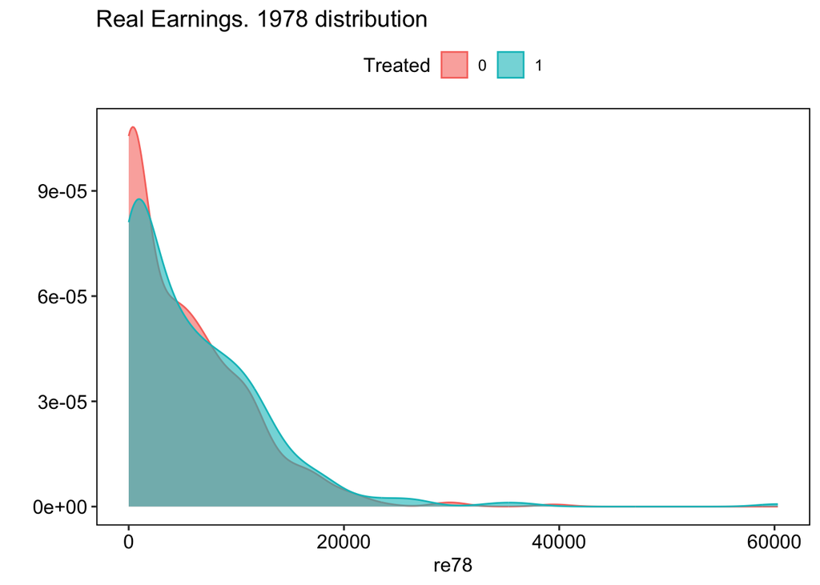

```r
###--- Experiment data. Treatment effect
tbl_exp |>
  ggplot(aes(re78, color = treat, fill = treat)) +
  geom_density(alpha = .6) +
  labs(title = "Real Earnings. 1978 distribution",
       color = "Treated",
       fill = "Treated",
       y = "")
```

```r
m1 <- lm(f5_outcome,
         data = tbl_exp)

tidy(m1) |>
  kable() |>
  kable_styling()
```

| term | estimate | std.error | statistic | p.value |
| --- | --- | --- | --- | --- |
| (Intercept) | 5090.0482 | 302.7826 | 16.810898 | 0.0000000 |
| treat1 | 886.3038 | 472.0863 | 1.877419 | 0.0608647 |

**The treated had earnings that were an average of 886 dollars higher than the controls in 1978.**

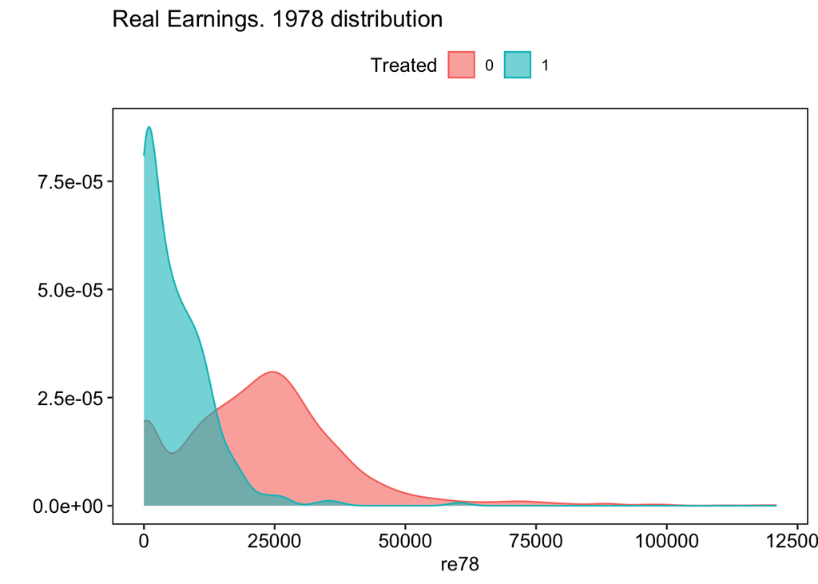

```r
###--- Observational data. Naive treatment effect
tbl |>
  ggplot(aes(re78, color = treat, fill = treat)) +
  geom_density(alpha = .6) +
  labs(title = "Real Earnings. 1978 distribution",
       color = "Treated",
       fill = "Treated",
       y = "")
```

```r
tbl |>
  group_by(treat) |>
  summarise(av_re = mean(re78)) |>
  pivot_wider(names_from = treat,
              values_from = av_re) |>
  mutate(diff = `1` - `0`)
```

```
## # A tibble: 1 × 3
##      `0`   `1`    diff
##    <dbl> <dbl>   <dbl>
## 1 22518. 5976. -16541.
```

**The treated has earnings that were, on average, 16541 dollars lower than the observational “control” units.**

### Question 2

Try to estimate the effect of the treatment using regression. What does regression say the effect of the program is?

```r
m2 <- lm(f5_outcome,
         data = tbl)

tidy(m2)
```

```
## # A tibble: 2 × 5
##   term        estimate std.error statistic  p.value
##   <chr>          <dbl>     <dbl>     <dbl>    <dbl>
## 1 (Intercept)   22518.      319.      70.5 0
## 2 treat1       -16541.      928.     -17.8 5.54e-67
```

**The result is the same whether we use regression or simply averaging and substracting.**

### Question 3

Begin by exact matching on all the dummy variables. How many treated cases cannot be matched? What is the (FS)ATT estimate?

```r
###--- Exact matching
g1 <- matchit(f1_bin,
              data = tbl,
              method = "exact",
              estimand = "ATT")

g1_sum <- summary(g1)
g1_sum$nn
```

```
##                  Control Treated
## All (ESS)     2213.00000     297
## All           2213.00000     297
## Matched (ESS)   59.52143     287
## Matched       2092.00000     287
## Unmatched      121.00000      10
## Discarded        0.00000       0
```

```r
###--- Calculate ATT
m3 <- lm(formula = f5_outcome,
         data = tbl,
         weights = g1$weights)

tidy(m3)
```

```
## # A tibble: 2 × 5
##   term        estimate std.error statistic   p.value
##   <chr>          <dbl>     <dbl>     <dbl>     <dbl>
## 1 (Intercept)    8244.      232.     35.6  1.27e-222
## 2 treat1        -2386.      667.     -3.58 3.54e-  4
```

**There are 10 treated units that could not be matched. The estimated ATT is -2386, meaning that matched controls made on average 2386 mode dollars on average that treatment units in 1978.**

### Question 4

Use the observational data to estimate each case’s propensity to receive treatment using glm(). Use a logistic regression with quadratic terms for age, education, 1974 income, and 1975 income. Spend a few moments thinking about what this model says. If you are familiar with plotting in R, look at the density plots of the p-score for treated and untreated groups. (If not, you can move on. We’ll do the same thing using bal.plot() in a bit.)

```r
###--- Fit the model
m4 <- glm(f3_quad,
          data = tbl,
          family = binomial(link = "logit"))


###--- Inspect the model
tidy(m4) |>
  kable() |>
  kable_styling()
```

| term | estimate | std.error | statistic | p.value |
| --- | --- | --- | --- | --- |
| (Intercept) | -4.0860109 | 2.0931327 | -1.9521032 | 0.0509260 |
| age | 0.0885744 | 0.0972988 | 0.9103334 | 0.3626467 |
| I(age^2) | -0.0029497 | 0.0014994 | -1.9673100 | 0.0491475 |
| educ | 0.8446841 | 0.3120974 | 2.7064765 | 0.0068001 |
| I(educ^2) | -0.0468130 | 0.0162233 | -2.8855303 | 0.0039075 |
| black | 1.9621150 | 0.2719006 | 7.2162949 | 0.0000000 |
| hisp | 2.4117400 | 0.4512282 | 5.3448340 | 0.0000001 |
| married | -2.0307420 | 0.2332962 | -8.7045654 | 0.0000000 |
| nodegr | 0.0177758 | 0.3420739 | 0.0519649 | 0.9585567 |
| re74 | -0.0000560 | 0.0000511 | -1.0956914 | 0.2732138 |
| I(re74^2) | 0.0000000 | 0.0000000 | 0.7276493 | 0.4668283 |
| re75 | -0.0001544 | 0.0000418 | -3.6900456 | 0.0002242 |
| I(re75^2) | 0.0000000 | 0.0000000 | 0.3580830 | 0.7202812 |
| u74 | 2.3537938 | 0.4966435 | 4.7394035 | 0.0000021 |
| u75 | -1.2273787 | 0.4540319 | -2.7032874 | 0.0068657 |

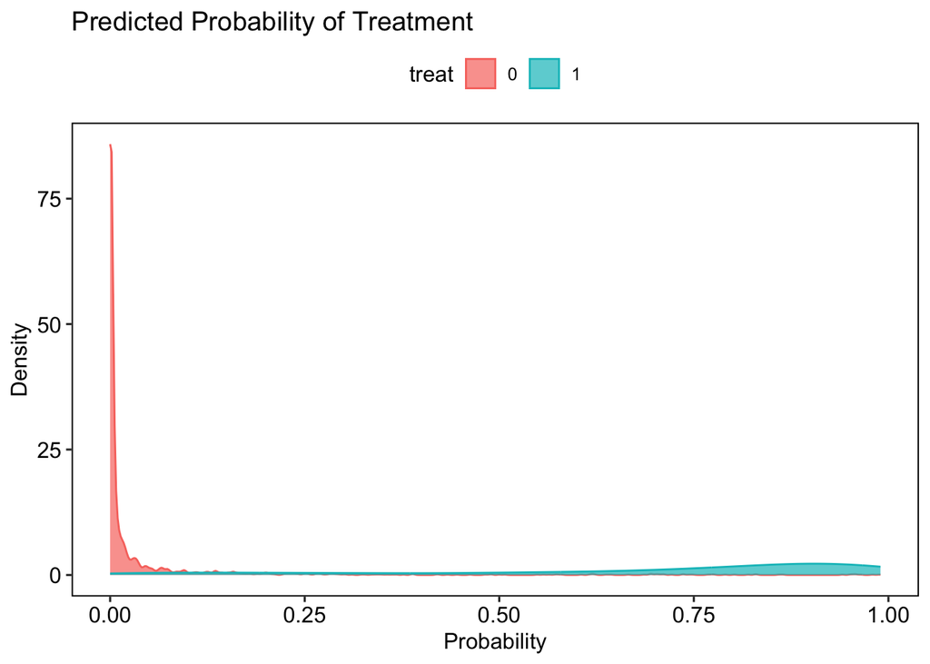

```r
###--- Calculate p scores
p_scores <-
  predict(m4, newdata = tbl) |>
  enframe(name = "case",
          value = "log_odds") |>
  mutate(odds = exp(log_odds),
         p_score = odds/(1 + odds)) |>
  bind_cols(treat = tbl |>
              select(treat))

###--- Plot
p_scores |>
  ggplot(aes(p_score, fill = treat, color = treat)) +
  geom_density(alpha = .7) +
  labs(title = "Predicted Probability of Treatment",
       x = "Probability",
       y = "Density")
```

### Question 5

Conduct 1:1 nearest-neighbor matching on the log odds of the propensity score. Use bal.plot() to compare the overall propensity score distributions. Do once without replacement and once with replacement. Why do you think there’s a difference? Try to figure it out. Estimate the ATT for each assumption (i.e., with or without replacement). If you achieve good overall balance on the propensity score, try checking individual covariate balance using love.plot().

```r
res <- list()


for(i in 0:1) {

  ###--- Match
  g2 <- matchit(formula = f3_quad,
              data = tbl,
              method = "nearest",
              distance = p_scores$log_odds,
              replace = as.logical(i))

  ###--- Love plot
  lp <- love.plot(g2)

  ###--- Extract max weight
  max_w <- max(g2$weights)


  ###--- Calcultate ATT
  m <- lm(formula = f5_outcome,
          data = tbl,
          weights = g2$weights)

  att <-
    m |>
    tidy() |>
    filter(term == "treat1") |>
    mutate(replace = as.logical(i)) |>
    relocate(replace)

  ###--- Plot
  dist_plot <-
    bal.plot(g2,which = "both") +
    labs(title = "Balance for Log Odds of Treatment",
         subtitle = glue("Replace = {as.logical(i)}"),
         x = "Log Odds")

  ###--- Put all together
  res[[i + 1]] <- tibble(
    replace = as.logical(i),
    g = list(g2),
    love_plot = list(lp),
    max_w = max_w,
    att = list(att),
    dist_plot = list(dist_plot)
  )

}


res <- bind_rows(res)
```

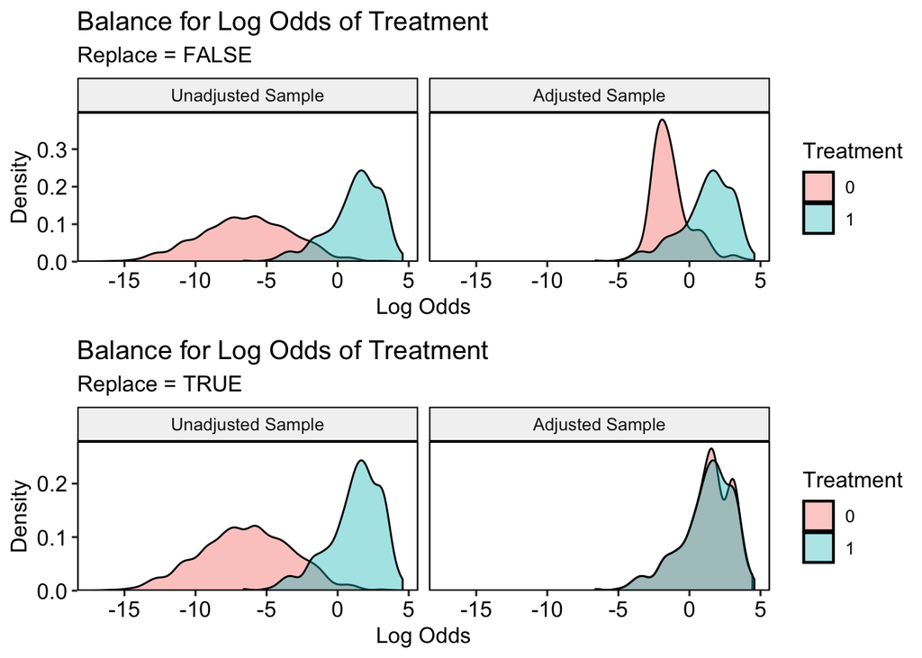

```r
###--- Plot balance in distance
cowplot::plot_grid(plotlist = res$dist_plot,nrow = 2)
```

```r
###--- Show maximum weights
res |>
  select(replace, max_w) |>
  kable(digits = 2) |>
  kable_styling()
```

| replace | max_w |
| --- | --- |
| FALSE | 1.00 |
| TRUE | 10.96 |

```r
###--- ATT
res |>
  pull(att) |>
  bind_rows() |>
  kable(digits = 2) |>
  kable_styling()
```

| replace | term | estimate | std.error | statistic | p.value |
| --- | --- | --- | --- | --- | --- |
| FALSE | treat1 | -3828.97 | 727.72 | -5.26 | 0.00 |
| TRUE | treat1 | -183.17 | 824.03 | -0.22 | 0.82 |

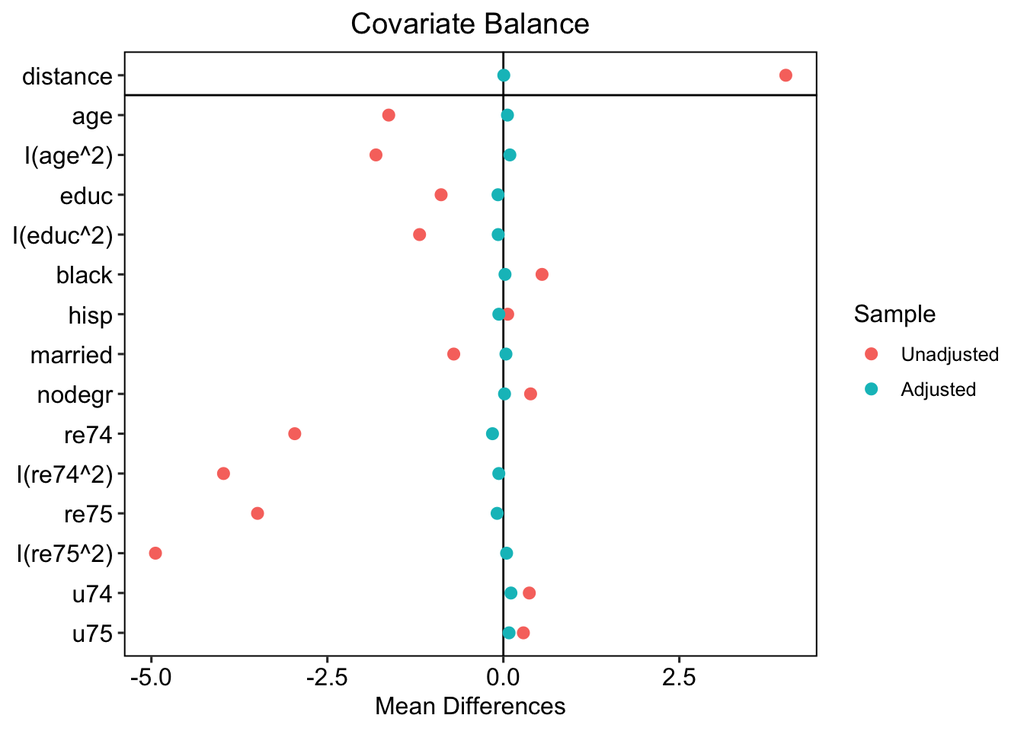

```r
###--- Love plot
res |>
  filter(replace == TRUE) |>
  pull(love_plot)
```

**Since balance on the propoensity scores was better when replace = TRUE I plot the balance on the covariates for that specification. ALl covariates are balanced.**

### Question 6

Estimate propensity scores and ATT weights using weightit(). Ignore the warning you get. We’ll discuss that more in class. Estimate the ATT. Check for covariate balance.

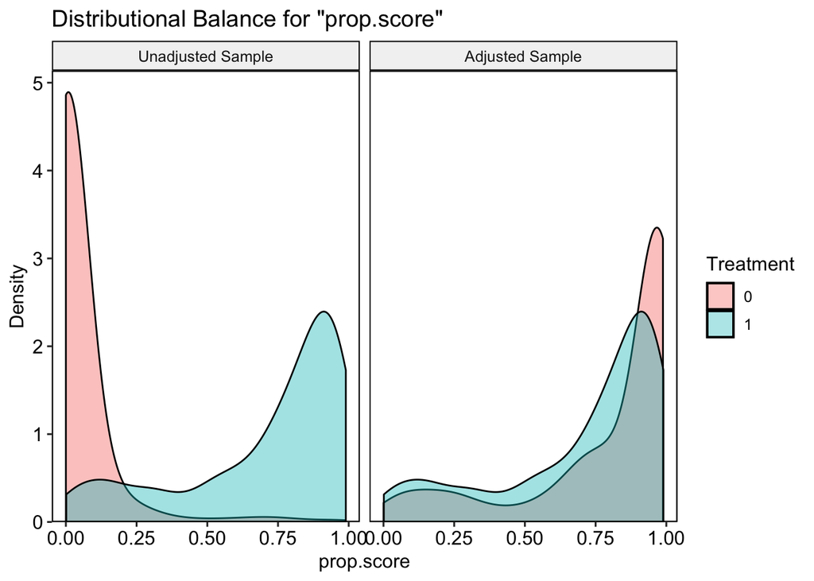

```r
g3 <- weightit(f3_quad,
               data = tbl,
               method = "ps",
               estimand = "ATT")


###--- Check for balance on ps
bal.plot(g3, which = "both")
```

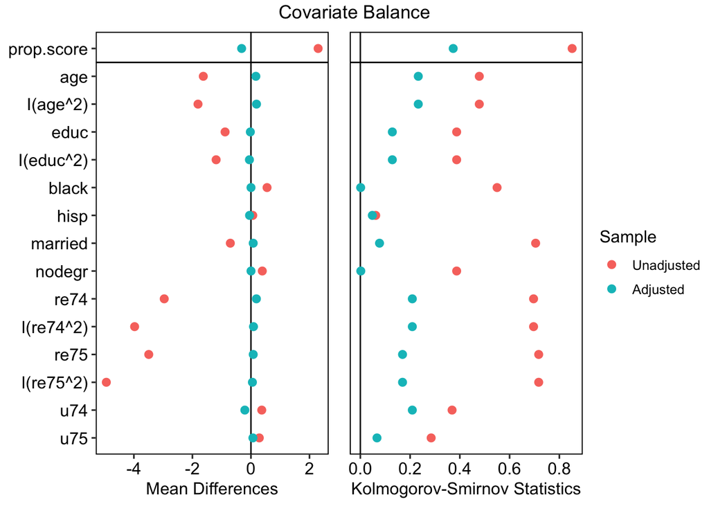

```r
###---- Check for balance on covariates
love.plot(g3,
          stats = c("m", "ks"))
```

```r
###--- Model treatment effect
m5 <- lm(f5_outcome,
         data = tbl,
         weights = g3$weights)

tidy(m5)
```

```
## # A tibble: 2 × 5
##   term        estimate std.error statistic   p.value
##   <chr>          <dbl>     <dbl>     <dbl>     <dbl>
## 1 (Intercept)    4837.      171.     28.2  1.78e-152
## 2 treat1         1139.      268.      4.25 2.23e-  5
```

**Covariate balance is fine. Accroding to this estimate, treatment has a positive effect. treated units were making 1139$ more than controls in 78. The estimate now is actually larger than the experimental one.**

### Question 7

Now do the same as above using covariate balancing propensity scores.

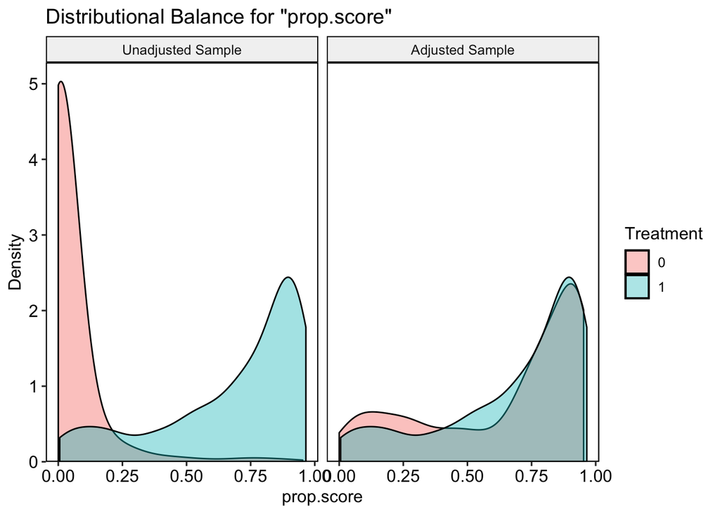

```r
g4 <- weightit(f3_quad,
               data = tbl,
               method = "cbps",
               estimand = "ATT")


###--- Check for balance on ps
bal.plot(g4, which = "both")
```

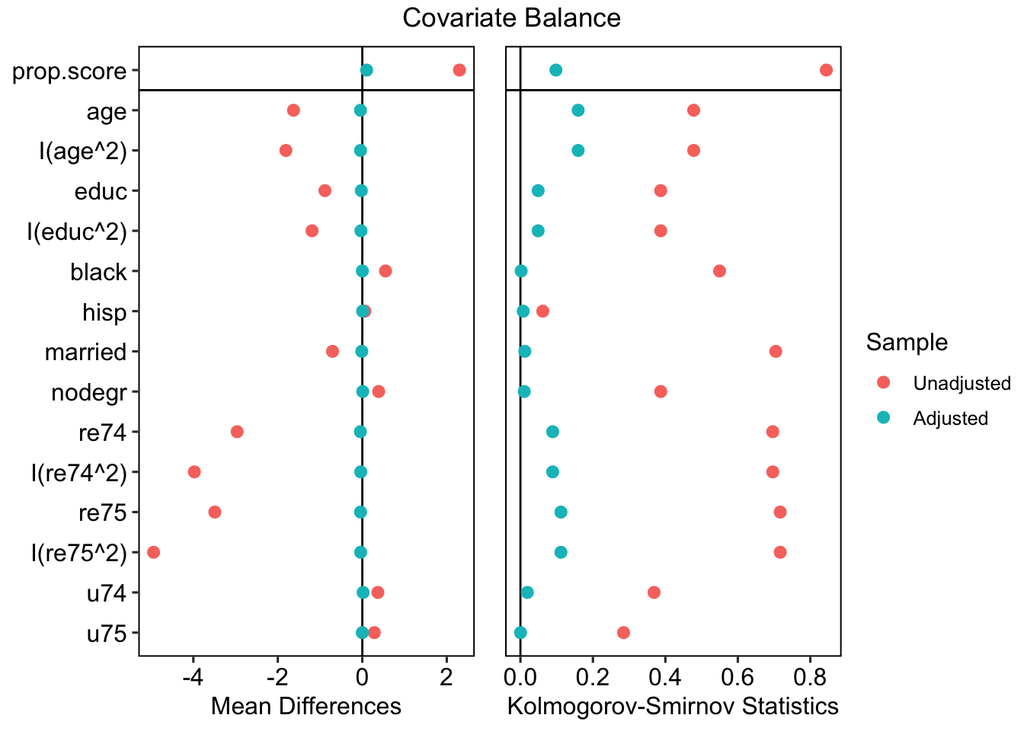

```r
###---- Check for balance on covariates
love.plot(g4,
          stats = c("m", "ks"))
```

```r
###--- Model treatment effect
m6 <- lm(f5_outcome,
         data = tbl,
         weights = g4$weights)

tidy(m6)
```

```
## # A tibble: 2 × 5
##   term        estimate std.error statistic   p.value
##   <chr>          <dbl>     <dbl>     <dbl>     <dbl>
## 1 (Intercept)   5907.       211.    28.0   1.08e-150
## 2 treat1          69.4      294.     0.236 8.13e-  1
```

**Balance looks a bit better now. However, the estimate if further away from the true estimate.**

### Question 8

Try Mahalanobis distance matching with replacement and using a caliper of .1. How many unique control cases get matched?

```r
g5 <- matchit(f3_quad,
              data = tbl,
              mahvars = f3_quad,
              distance = "glm",
              estimand = "ATT",
              caliper = .1)

g5_sum <- summary(g5)
g5_sum |> pluck("nn")
```

```
##               Control Treated
## All (ESS)        2213     297
## All              2213     297
## Matched (ESS)     111     111
## Matched           111     111
## Unmatched        2102     186
## Discarded           0       0
```

```r
m7 <- lm(f5_outcome,
         data = tbl,
         weights = g5$weights)

tidy(m7)
```

```
## # A tibble: 2 × 5
##   term        estimate std.error statistic  p.value
##   <chr>          <dbl>     <dbl>     <dbl>    <dbl>
## 1 (Intercept)    8611.      768.     11.2  2.29e-23
## 2 treat1        -2096.     1086.     -1.93 5.49e- 2
```

**Only 111 controls were matched.**

### Question 9

Use entropy balancing to balance treatment and control. Confirm that you’ve achieved balance on the means and the variances of the covariates.

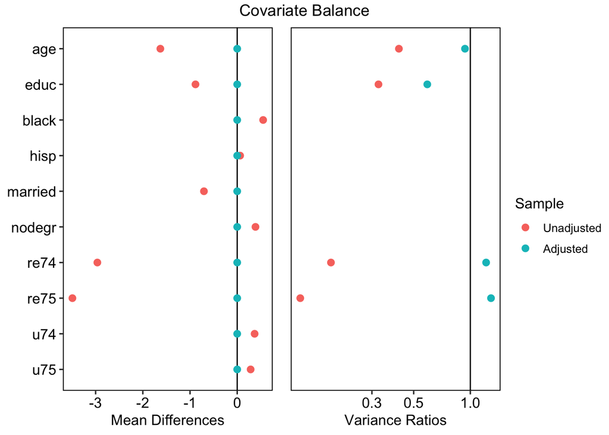

```r
g6 <- weightit(f2_lin,
               data = tbl,
               method = "ebal",
               estimand = "ATT")


love.plot(g6,
          stats = c("m", "v"))
```

```r
m8 <- lm(f5_outcome,
         data = tbl,
         weights = g6$weights)

tidy(m8)
```

```
## # A tibble: 2 × 5
##   term        estimate std.error statistic   p.value
##   <chr>          <dbl>     <dbl>     <dbl>     <dbl>
## 1 (Intercept)    5649.      157.    36.0   4.15e-229
## 2 treat1          327.      456.     0.718 4.73e-  1
```

**It achieves balance on the means. Not so sure on the variance.**

### Question 10

Now revisit questions 3 and 5-9. This time, instead of just using simple regressions to estimate the ATT, estimate full outcome regressions using the dataset you “preprocesssed” with matching or weighting. How does this affect the estimates?

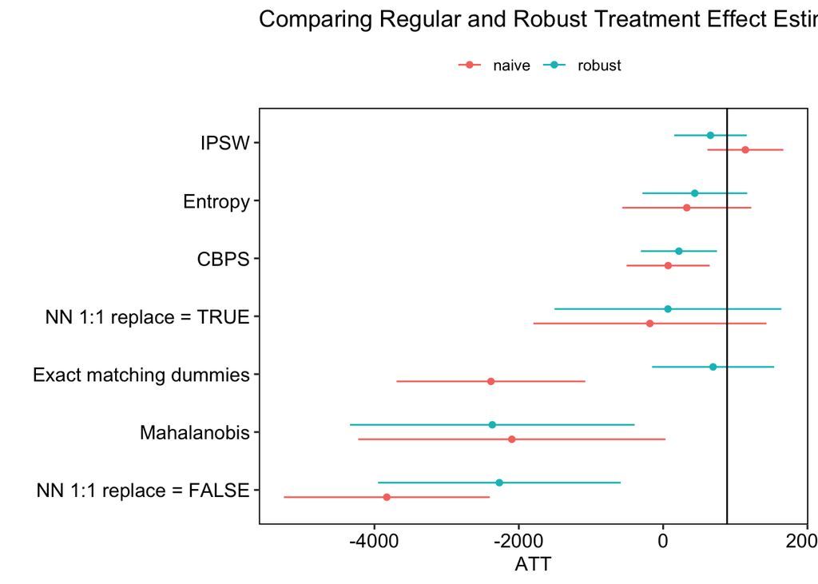

```r
###--- Weights

###--- Put together weights for all models
weights <-
  tribble(~ "weights", ~ "description",
          g1$weights, "Exact matching dummies",
          res$g[[1]]$weights, "NN 1:1 replace = FALSE",
          res$g[[2]]$weights,"NN 1:1 replace = TRUE",
          g3$weights, "IPSW",
          g4$weights, "CBPS",
          g5$weights, "Mahalanobis",
          g6$weights, "Entropy")


###---
get_t_effect <- function(w, type) {

  if(type == "naive") f <- f5_outcome
  else f <- f4_outcome

  tbl <- tbl |>  bind_cols(weights = w)

  est <-
    lm(f,
     data = tbl,
     weights = weights) |>
  tidy() |>
  filter(term == "treat1") |>
  mutate(model = !!type) |>
  select(model,
         estimate,
         std_error = std.error)

  return(est)

}


###--- Wrangle the data
weights <-
  weights |>
  mutate(naive = map(weights, get_t_effect, type = "naive"),
         robust = map(weights, get_t_effect, type = "robust")) |>
  select(-weights)


weights <-
  weights |>
  pivot_longer(cols = c(robust,naive),
               names_to = "type",
               values_to = "est") |>
  unnest(est)


###--- Plot

weights |>
  mutate(
    conf_low = estimate - 1.96 * std_error,
    conf_high = estimate + 1.96 * std_error,
    description = fct_reorder(description, estimate)) |>
  ggplot(aes(estimate, description, color = type)) +
  geom_point(position = position_dodge(width = .5)) +
  geom_linerange(aes(xmin = conf_low, xmax = conf_high),
                 position = position_dodge(width = .5)) +
  labs(title = "Comparing Regular and Robust Treatment Effect Estimation",
       y = "",
       x = "ATT",
       color = "") +
  geom_vline(aes(xintercept = 886))
```

### Question 11

Implement a bootstrap of your preferred estimate. What is the bootstrapped standard error?

```r
n <- 1e2
res <- c()

for(i in 1:n) {

  tbl_boot <- tbl[sample(nrow(tbl),replace = TRUE),]

  ###--- Calculate IPSW
  g <- suppressWarnings(weightit(f3_quad,
              data = tbl_boot,
              method = "ps",
              estimand = "ATT"))

  ###--- Model treatment effect
  est <- lm(f5_outcome,
           data = tbl_boot,
           weights = g$weights)

  res[i] <- as.numeric(coef(est)["treat1"])

  if(i %% 10 == 0) print(i)
}
```

```
## [1] 10
## [1] 20
## [1] 30
## [1] 40
## [1] 50
## [1] 60
## [1] 70
## [1] 80
## [1] 90
## [1] 100
```

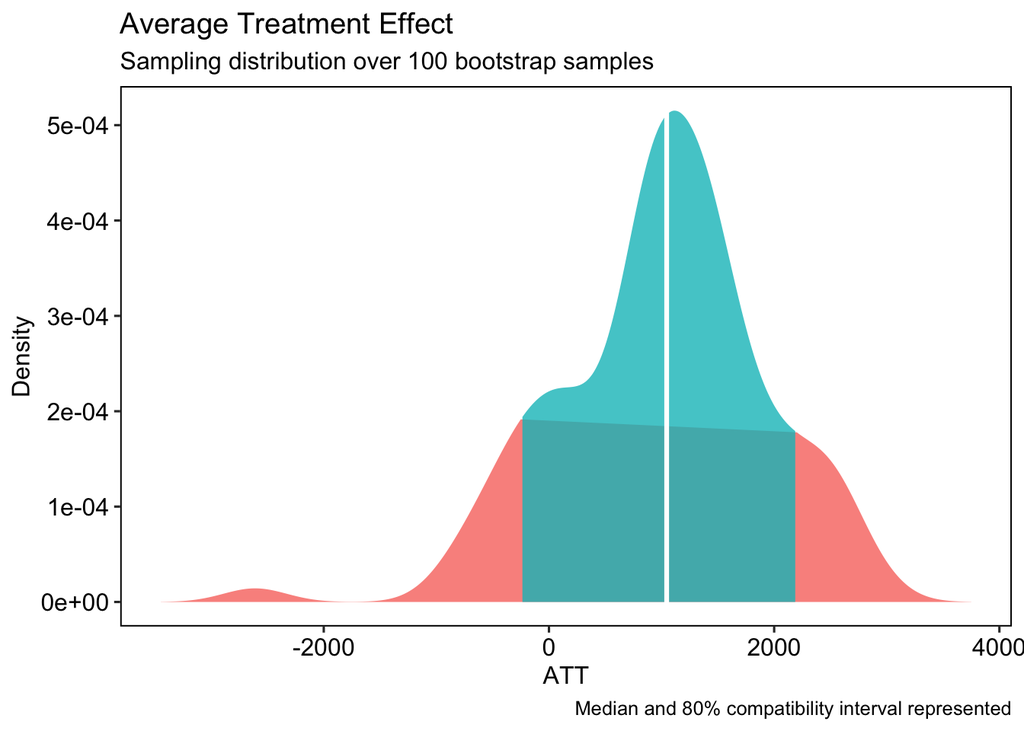

```r
###--- Plot it

res_sum <-
  res |>
  as_tibble() |>
  summarise(median = median(value),
         pct_2 = rethinking::PCI(value,prob = .8)[1],
         pct_98 = rethinking::PCI(value,prob = .8)[2])


dens <- density(res)

dens <-  tibble(x = dens$x,
                y = dens$y) |>
  mutate(area = if_else(x >= res_sum$pct_2 &
                        x <= res_sum$pct_98,
                        TRUE,FALSE))


dens |>
  ggplot(aes(x = x, ymin = 0, ymax = y, fill = area)) +
  geom_ribbon(alpha = .8) +
  geom_vline(aes(xintercept = res_sum$median),
             color = "white",
             linewidth = 1.1) +
  theme(legend.position = "none") +
  labs(title = "Average Treatment Effect",
       subtitle = glue("Sampling distribution over {n} bootstrap samples"),
       caption = "Median and 80% compatibility interval represented",
       x = "ATT",
       y = "Density")
```

```r
###--- Bootstrapped SE
sd(res)/sqrt(n - 1)
```

```
## [1] 92.88386
```

```r
mean(res)
```

```
## [1] 1002.665
```

```r
f1 <- function(tbl, i ) {
    ###--- Calculate IPSW
  g <- suppressWarnings(weightit(f3_quad,
              data = tbl[i, ],
              method = "ps",
              estimand = "ATT"))

  ###--- Model treatment effect
  est <- lm(f5_outcome,
           data = tbl[i, ],
           weights = g$weights)

  res <- as.numeric(coef(est)["treat1"])
  return(res)
}


boot::boot(statistic = f1, data = tbl, R = 300)
```

```
##
## ORDINARY NONPARAMETRIC BOOTSTRAP
##
##
## Call:
## boot::boot(data = tbl, statistic = f1, R = 300)
##
##
## Bootstrap Statistics :
##      original    bias    std. error
## t1* -15617.31 -930.6964    2302.643
```

**Those estimate are definitely not right but I can’t figure out what’s wrong.**